# 08 — Comprehensive Detector Validation

**Author:** Zeineb Turki  
**Date:** April 2026  
**Phase:** Pattern Validation

## Objective

Validate ALL pattern detectors on BOTH data sources (yfinance and Alpha Vantage) with:

1. **Quantitative comparison** — detection counts, confidence metrics, cross-source consistency
2. **Visual examples** — candlestick charts with overlaid trendlines, touch markers, and event signals for each detector type
3. **Labeling analysis** — triple-barrier label distributions and confusion matrices
4. **Source overlap** — Jaccard similarity of event dates between sources

**Why this matters:**

- Visual inspection confirms detectors are finding real patterns, not noise
- Cross-source validation ensures robustness to vendor-specific data quirks
- Label distributions reveal whether the training set is balanced enough for modeling

**Note:** If the Alpha Vantage API key is not available, the second source is simulated with small random noise (same approach as notebook 07).

```python
import sys, os
from pathlib import Path

# Clear cached src modules for clean reload
for mod_name in list(sys.modules.keys()):
    if mod_name.startswith('src'):
        del sys.modules[mod_name]

# Environment setup: Colab or local
if 'google.colab' in str(getattr(sys, 'modules', {})) or os.path.exists('/content'):
    REPO_DIR  = '/content/regime-aware-ml-trading'
    PROJ_ROOT = os.path.join(REPO_DIR, 'regime-aware-ml-trading')
    if not os.path.isdir(PROJ_ROOT):
        os.system('git clone https://github.com/zaetae/regime-aware-ml-trading.git ' + REPO_DIR)
    else:
        os.system(f'cd {REPO_DIR} && git pull -q')
    os.system(f'{sys.executable} -m pip install -q yfinance hmmlearn scikit-learn seaborn statsmodels')
    _spy_path = os.path.join(PROJ_ROOT, 'data', 'raw', 'spy.csv')
    if not os.path.isfile(_spy_path):
        os.makedirs(os.path.dirname(_spy_path), exist_ok=True)
        import yfinance as yf
        import pandas as pd
        _spy = yf.download('SPY', start='2010-01-01', end='2026-01-01', auto_adjust=False)
        if isinstance(_spy.columns, pd.MultiIndex):
            _spy.columns = _spy.columns.droplevel(1)
        _spy = _spy[['Open', 'High', 'Low', 'Close', 'Volume']]
        if _spy.index.tz is not None:
            _spy.index = _spy.index.tz_localize(None)
        _spy.index.name = 'Date'
        _spy.to_csv(_spy_path)
        print(f"Downloaded SPY data to {_spy_path}")
else:
    def _find_project_root():
        current = Path.cwd()
        for _ in range(10):
            if (current / "src").is_dir():
                return current
            current = current.parent
        return Path.cwd().parent if (Path.cwd().parent / "src").is_dir() else Path.cwd()
    PROJ_ROOT = str(_find_project_root())

sys.path.insert(0, PROJ_ROOT)
os.chdir(PROJ_ROOT)

%matplotlib inline
import numpy as np
import pandas as pd
import matplotlib.pyplot as plt
import matplotlib.dates as mdates
import seaborn as sns
import warnings
warnings.filterwarnings('ignore')

from src.data.load_data import load_spy, load_spy_alphavantage, compare_sources
from src.data.utils import compute_atr
from src.patterns.scanner import scan_all_patterns
from src.patterns.triangles import detect_triangle_pattern
from src.patterns.channels import detect_channel
from src.patterns.support_resistance import calculate_support_resistance
from src.patterns.multiple_tops_bottoms import detect_multiple_tops_bottoms
from src.labeling.label_events import label_events
from src.utils.plotting import plot_candlestick, add_trendline, add_event_marker
from sklearn.metrics import confusion_matrix, ConfusionMatrixDisplay

sns.set_style('whitegrid')
plt.rcParams['figure.dpi'] = 100

print('Imports OK')
```

```
Imports OK
```

## 1. Load Both Data Sources

Load the yfinance CSV (primary) and Alpha Vantage (secondary). If the Alpha Vantage API key is not available, simulate the second source with small random noise.

```python
# --- Source 1: yfinance CSV (always available) ---
df_yf = load_spy(source='csv')
print(f'yfinance CSV: {len(df_yf)} rows, {df_yf.index[0].date()} to {df_yf.index[-1].date()}')

# --- Source 2: Alpha Vantage (may require API key) ---
SIMULATED = False
try:
    df_av = load_spy_alphavantage()
    source_label = 'Alpha Vantage (real)'
    print(f'Alpha Vantage: {len(df_av)} rows, {df_av.index[0].date()} to {df_av.index[-1].date()}')
except (ValueError, Exception) as e:
    SIMULATED = True
    source_label = 'Alpha Vantage (simulated)'
    print(f'Alpha Vantage not available: {e}')
    print('>>> Simulating second source with small random noise.')
    print()

    rng = np.random.default_rng(42)
    df_av = df_yf.copy()

    # Add small price noise (~0.01% std) to OHLC columns
    for col in ['Open', 'High', 'Low', 'Close']:
        noise = rng.normal(loc=0.0, scale=0.0001, size=len(df_av))
        df_av[col] = df_av[col] * (1 + noise)

    # Add volume noise (~0.5% std)
    vol_noise = rng.normal(loc=0.0, scale=0.005, size=len(df_av))
    df_av['Volume'] = (df_av['Volume'] * (1 + vol_noise)).astype(int)

    # Drop a few random dates to simulate coverage differences
    drop_idx = rng.choice(len(df_av), size=5, replace=False)
    df_av = df_av.drop(df_av.index[drop_idx])

    print(f'Simulated source: {len(df_av)} rows, {df_av.index[0].date()} to {df_av.index[-1].date()}')

print()
print(f'{"Source":<30} {"Rows":>6}  {"Start":>12}  {"End":>12}')
print('-' * 65)
print(f'{"yfinance CSV":<30} {len(df_yf):>6}  {str(df_yf.index[0].date()):>12}  {str(df_yf.index[-1].date()):>12}')
print(f'{source_label:<30} {len(df_av):>6}  {str(df_av.index[0].date()):>12}  {str(df_av.index[-1].date()):>12}')
```

```
yfinance CSV: 4023 rows, 2010-01-04 to 2025-12-30
Alpha Vantage not available: Alpha Vantage API key required. Set ALPHAVANTAGE_API_KEY env var or pass api_key='...'.
>>> Simulating second source with small random noise.

Simulated source: 4018 rows, 2010-01-04 to 2025-12-30

Source                           Rows         Start           End
-----------------------------------------------------------------
yfinance CSV                     4023    2010-01-04    2025-12-30
Alpha Vantage (simulated)        4018    2010-01-04    2025-12-30
```

## 2. Run All Detectors on Both Sources

Run `scan_all_patterns()` on both datasets and compare detection counts per pattern type with a side-by-side table and grouped bar chart.

```python
print('Running pattern scanner on yfinance data...')
df_yf_scanned = scan_all_patterns(df_yf.copy())
print('Running pattern scanner on Alpha Vantage data...')
df_av_scanned = scan_all_patterns(df_av.copy())
print('Done.\n')

# Detection counts
pattern_cols = {
    'Near Support':     'near_support',
    'Near Resistance':  'near_resistance',
    'Triangle':         'triangle_pattern',
    'Multi Top/Bottom': 'multiple_top_bottom_pattern',
    'Channel':          'channel_pattern',
    'Any Event':        'has_event',
}

detection_comparison = []
for name, col in pattern_cols.items():
    if col in ['near_support', 'near_resistance', 'has_event']:
        yf_count = int(df_yf_scanned[col].sum())
        av_count = int(df_av_scanned[col].sum())
    else:
        yf_count = int(df_yf_scanned[col].notna().sum())
        av_count = int(df_av_scanned[col].notna().sum())
    detection_comparison.append({
        'Pattern': name,
        'yfinance': yf_count,
        source_label: av_count,
        'Difference': av_count - yf_count,
        'Match %': round(min(yf_count, av_count) / max(yf_count, 1) * 100, 1),
    })

det_df = pd.DataFrame(detection_comparison)
print('Pattern Detection Comparison')
print('=' * 75)
print(det_df.to_string(index=False))
```

```
Running pattern scanner on yfinance data...
```

```
Running pattern scanner on Alpha Vantage data...
```

```
Done.

Pattern Detection Comparison
===========================================================================
         Pattern  yfinance  Alpha Vantage (simulated)  Difference  Match %
    Near Support         5                          6           1    100.0
 Near Resistance        37                         35          -2     94.6
        Triangle        22                         23           1    100.0
Multi Top/Bottom        63                         62          -1     98.4
         Channel        12                         12           0    100.0
       Any Event       137                        137           0    100.0
```

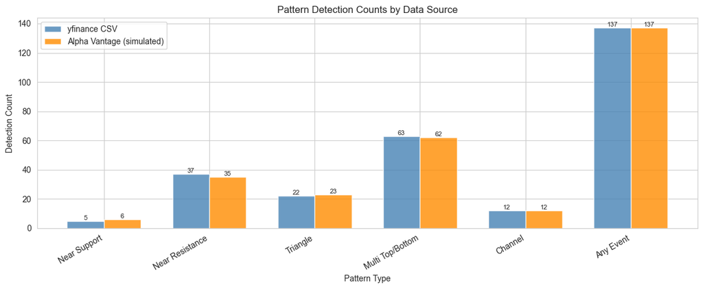

```python
# Grouped bar chart: detection counts by source
fig, ax = plt.subplots(figsize=(12, 5))

patterns = det_df['Pattern'].tolist()
x = np.arange(len(patterns))
width = 0.35

bars1 = ax.bar(x - width/2, det_df['yfinance'], width, label='yfinance CSV',
               color='steelblue', alpha=0.8)
bars2 = ax.bar(x + width/2, det_df[source_label], width, label=source_label,
               color='darkorange', alpha=0.8)

ax.set_xlabel('Pattern Type')
ax.set_ylabel('Detection Count')
ax.set_title('Pattern Detection Counts by Data Source')
ax.set_xticks(x)
ax.set_xticklabels(patterns, rotation=30, ha='right')
ax.legend()

for bar in bars1:
    h = bar.get_height()
    ax.annotate(f'{int(h)}', xy=(bar.get_x() + bar.get_width()/2, h),
                ha='center', va='bottom', fontsize=8)
for bar in bars2:
    h = bar.get_height()
    ax.annotate(f'{int(h)}', xy=(bar.get_x() + bar.get_width()/2, h),
                ha='center', va='bottom', fontsize=8)

plt.tight_layout()
plt.show()
```

## 3. Channel Detector -- Visual Examples

Run `detect_channel(df_yf, return_details=True)` and plot the first 6 detections. Each chart shows:

- Candlestick bars covering the channel window + 10 bars forward context
- **Red line** = upper trendline, **blue line** = lower trendline (extended 3 bars past the end)
- **Gold stars** at upper touch indices (placed at High price)
- **Cyan stars** at lower touch indices (placed at Low price)
- **Orange diamond** at the breakout/event bar

```
Channel detections: 12

Showing 6 channel examples:
```

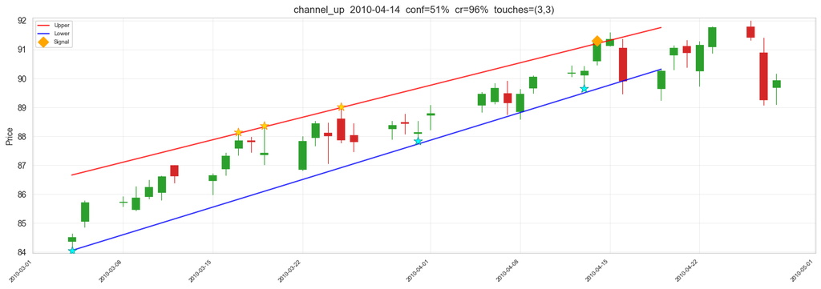

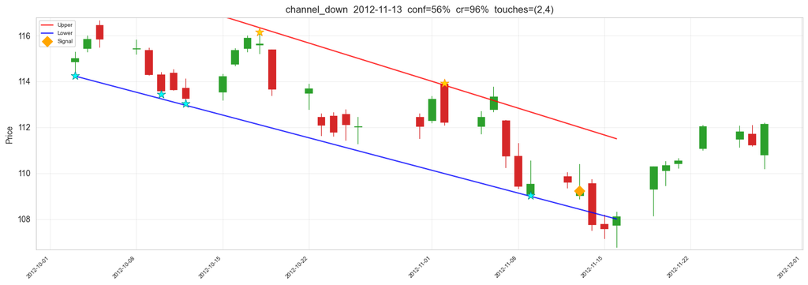

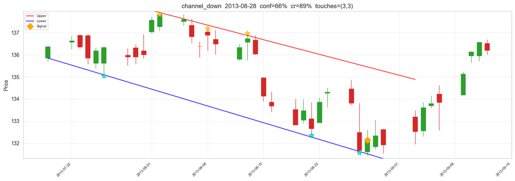

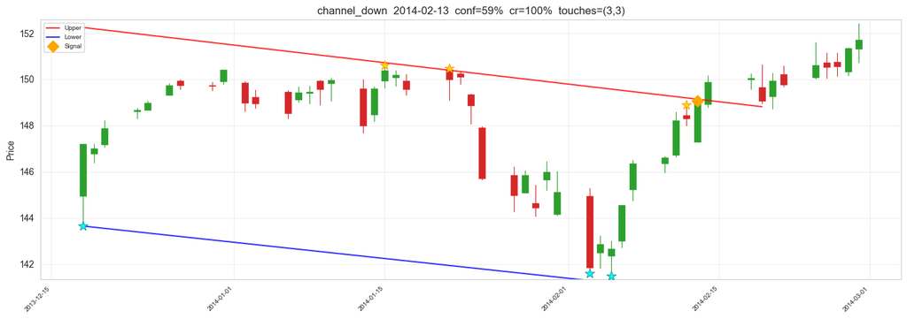

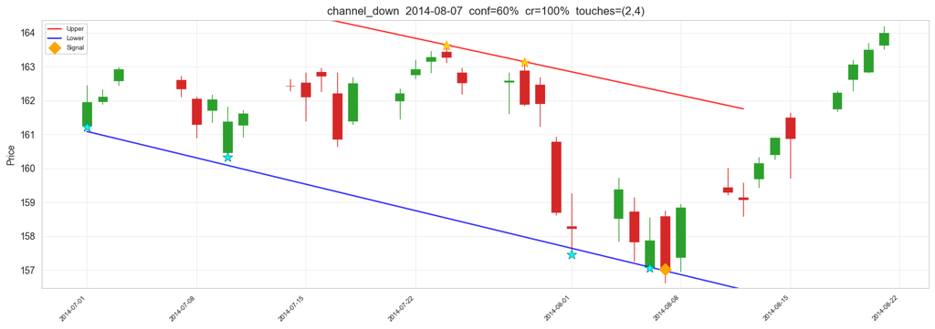

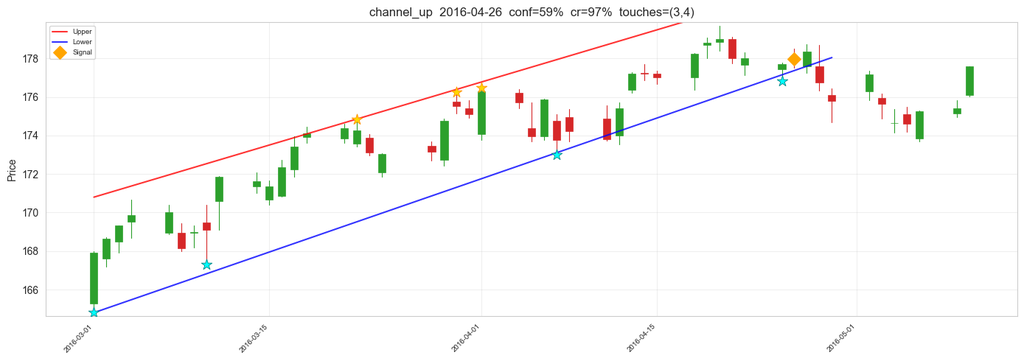

```python
# Run channel detector with details
_, channel_details = detect_channel(df_yf.copy(), return_details=True)
print(f'Channel detections: {len(channel_details)}')

def plot_channel_detection(det, df):
    """Plot a single channel detection with trendlines and touch markers."""
    FORWARD = 10
    start = det['start_idx']
    end = min(det['end_idx'] + FORWARD, len(df) - 1)
    chart = df.iloc[start:end + 1]

    title = f"{det['pattern_type']}  {det['event_date'].strftime('%Y-%m-%d')}"
    title += f"  conf={det.get('confidence', 0):.0f}%"
    title += f"  cr={det['containment_ratio']:.0%}"
    title += f"  touches=({det['upper_touches']},{det['lower_touches']})"

    fig, ax = plt.subplots(figsize=(14, 5))
    plot_candlestick(chart, ax=ax, title=title)

    # Draw trendlines from window start to 3 bars past end
    x_start = 0
    x_end = min(det['end_idx'] - start + 3, len(chart) - 1)
    d_start = mdates.date2num(df.index[start])
    d_end = mdates.date2num(df.index[min(start + x_end, len(df) - 1)])

    sl_u, ic_u = det['upper_slope'], det['upper_intercept']
    sl_l, ic_l = det['lower_slope'], det['lower_intercept']
    ax.plot([d_start, d_end], [sl_u * x_start + ic_u, sl_u * x_end + ic_u],
            color='red', lw=1.5, alpha=0.8, label='Upper')
    ax.plot([d_start, d_end], [sl_l * x_start + ic_l, sl_l * x_end + ic_l],
            color='blue', lw=1.5, alpha=0.8, label='Lower')

    # Upper touch markers (gold stars at High)
    for idx in det.get('upper_touch_indices', []):
        if start <= idx <= end:
            ax.scatter(mdates.date2num(df.index[idx]), df['High'].iloc[idx],
                       marker='*', color='gold', s=120, zorder=7,
                       edgecolors='darkorange', linewidths=0.6)

    # Lower touch markers (cyan stars at Low)
    for idx in det.get('lower_touch_indices', []):
        if start <= idx <= end:
            ax.scatter(mdates.date2num(df.index[idx]), df['Low'].iloc[idx],
                       marker='*', color='cyan', s=120, zorder=7,
                       edgecolors='teal', linewidths=0.6)

    # Event marker (orange diamond)
    add_event_marker(ax, det['event_date'], df.loc[det['event_date'], 'Close'],
                     marker='D', color='orange', size=80, label='Signal')

    ax.legend(fontsize=7, loc='upper left')
    plt.tight_layout()
    plt.show()

# Plot first 6 channel detections
n_show = min(6, len(channel_details))
print(f'\nShowing {n_show} channel examples:\n')
for det in channel_details[:n_show]:
    plot_channel_detection(det, df_yf)
```

## 4. Triangle Detector -- Visual Examples

Run `detect_triangle_pattern(df_yf, return_details=True)` and plot the first 6 detections. Each chart shows:

- Candlestick bars covering the triangle window + 10 bars forward context
- **Red line** = upper trendline, **blue line** = lower trendline
- **Red down-arrows** at swing high pivot positions (placed at High price)
- **Blue up-arrows** at swing low pivot positions (placed at Low price)
- **Gold stars** at upper touch indices, **cyan stars** at lower touch indices
- **Orange diamond** at the breakout/event bar

```
Triangle detections: 22

Showing 6 triangle examples:
```

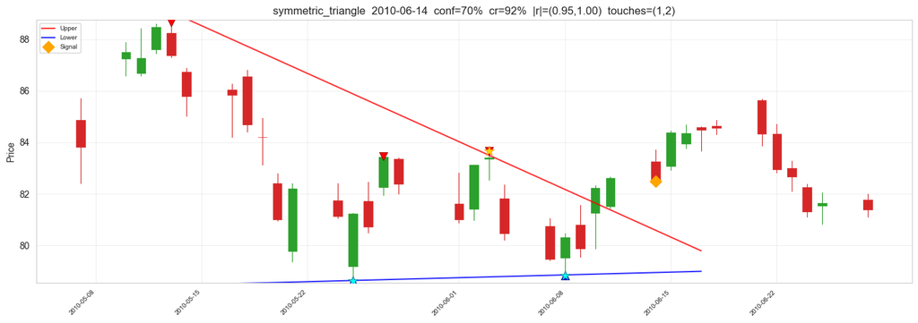

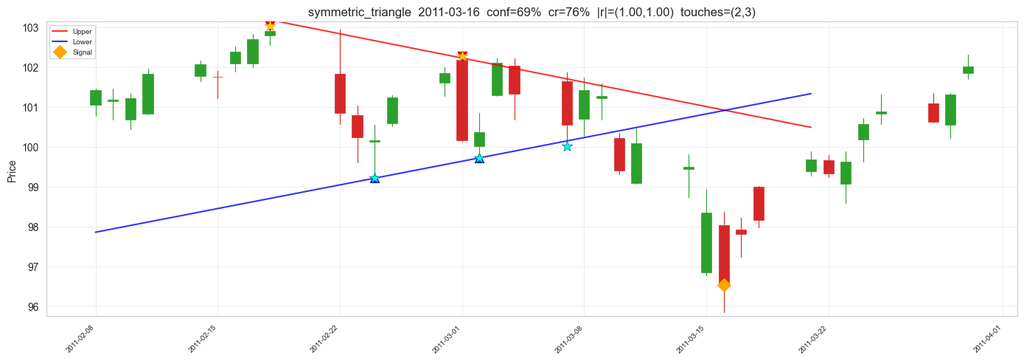

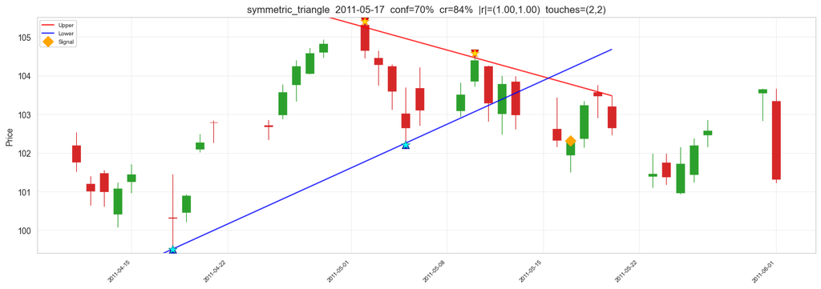

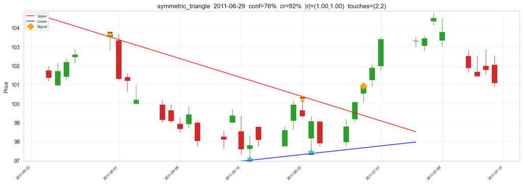

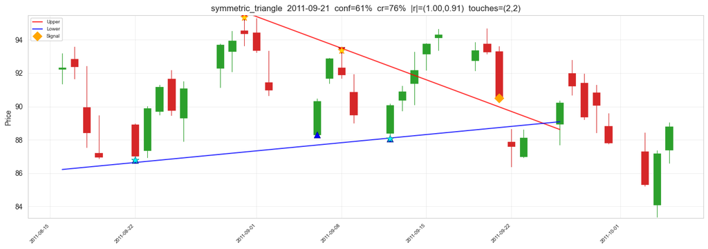

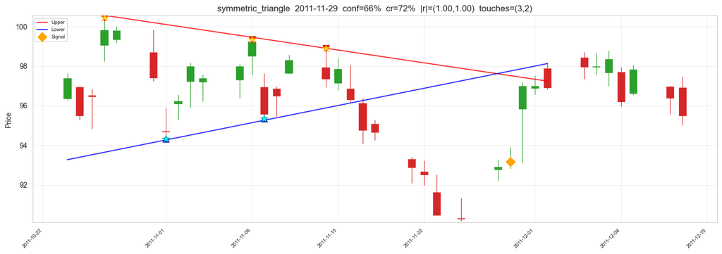

```python
# Run triangle detector with details
_, triangle_details = detect_triangle_pattern(df_yf.copy(), return_details=True)
print(f'Triangle detections: {len(triangle_details)}')

def plot_triangle_detection(det, df):
    """Plot a single triangle detection with trendlines, pivots, and touch markers."""
    FORWARD = 10
    start = det['start_idx']
    end = min(det['end_idx'] + FORWARD, len(df) - 1)
    chart = df.iloc[start:end + 1]

    title = f"{det['pattern_type']}  {det['event_date'].strftime('%Y-%m-%d')}"
    title += f"  conf={det.get('confidence', 0):.0f}%"
    title += f"  cr={det['containment_ratio']:.0%}"
    title += f"  |r|=({det.get('r_upper', 0):.2f},{det.get('r_lower', 0):.2f})"
    title += f"  touches=({det['upper_touches']},{det['lower_touches']})"

    fig, ax = plt.subplots(figsize=(14, 5))
    plot_candlestick(chart, ax=ax, title=title)

    # Draw trendlines
    x_start = 0
    x_end = min(det['end_idx'] - start + 3, len(chart) - 1)
    d_start = mdates.date2num(df.index[start])
    d_end = mdates.date2num(df.index[min(start + x_end, len(df) - 1)])

    sl_u, ic_u = det['upper_slope'], det['upper_intercept']
    sl_l, ic_l = det['lower_slope'], det['lower_intercept']
    ax.plot([d_start, d_end], [sl_u * x_start + ic_u, sl_u * x_end + ic_u],
            color='red', lw=1.5, alpha=0.8, label='Upper')
    ax.plot([d_start, d_end], [sl_l * x_start + ic_l, sl_l * x_end + ic_l],
            color='blue', lw=1.5, alpha=0.8, label='Lower')

    # Swing high pivots (red down-arrows at High)
    for idx, price in zip(det.get('swing_high_idx', []), det.get('swing_high_prices', [])):
        if start <= idx <= end:
            ax.scatter(mdates.date2num(df.index[idx]), price,
                       marker='v', color='red', s=80, zorder=7, edgecolors='darkred', linewidths=0.6)

    # Swing low pivots (blue up-arrows at Low)
    for idx, price in zip(det.get('swing_low_idx', []), det.get('swing_low_prices', [])):
        if start <= idx <= end:
            ax.scatter(mdates.date2num(df.index[idx]), price,
                       marker='^', color='blue', s=80, zorder=7, edgecolors='darkblue', linewidths=0.6)

    # Upper touch markers (gold stars at High)
    for idx in det.get('upper_touch_indices', []):
        if start <= idx <= end:
            ax.scatter(mdates.date2num(df.index[idx]), df['High'].iloc[idx],
                       marker='*', color='gold', s=120, zorder=7,
                       edgecolors='darkorange', linewidths=0.6)

    # Lower touch markers (cyan stars at Low)
    for idx in det.get('lower_touch_indices', []):
        if start <= idx <= end:
            ax.scatter(mdates.date2num(df.index[idx]), df['Low'].iloc[idx],
                       marker='*', color='cyan', s=120, zorder=7,
                       edgecolors='teal', linewidths=0.6)

    # Event marker (orange diamond)
    add_event_marker(ax, det['event_date'], df.loc[det['event_date'], 'Close'],
                     marker='D', color='orange', size=80, label='Signal')

    ax.legend(fontsize=7, loc='upper left')
    plt.tight_layout()
    plt.show()

# Plot first 6 triangle detections
n_show = min(6, len(triangle_details))
print(f'\nShowing {n_show} triangle examples:\n')
for det in triangle_details[:n_show]:
    plot_triangle_detection(det, df_yf)
```

## 5. Support/Resistance Detector -- Visual Examples

Run `calculate_support_resistance(df_yf)` and pick 4 events where `near_support` or `near_resistance` is True. For each, plot 60 bars of context centered on the event, with horizontal lines at the support/resistance levels and the event bar marked.

```
S/R events: 42  (support=5, resistance=37)

Showing 4 S/R examples:
```

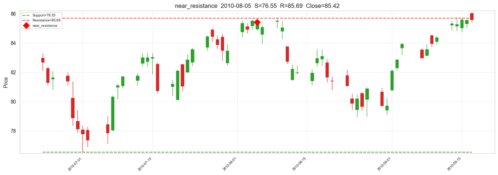

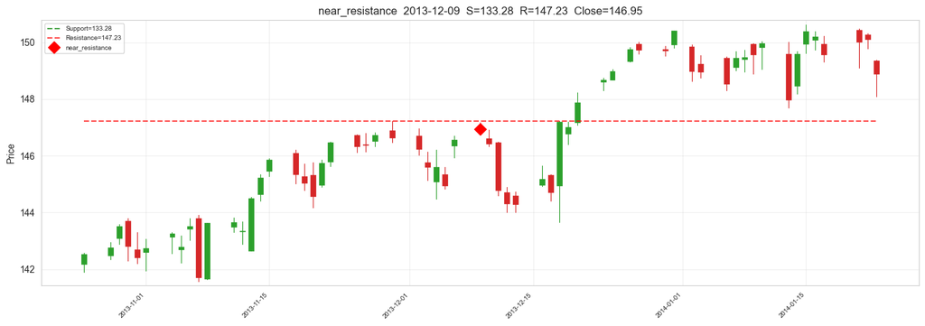

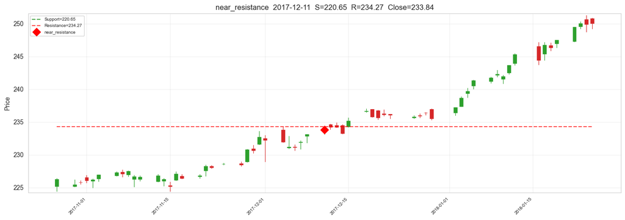

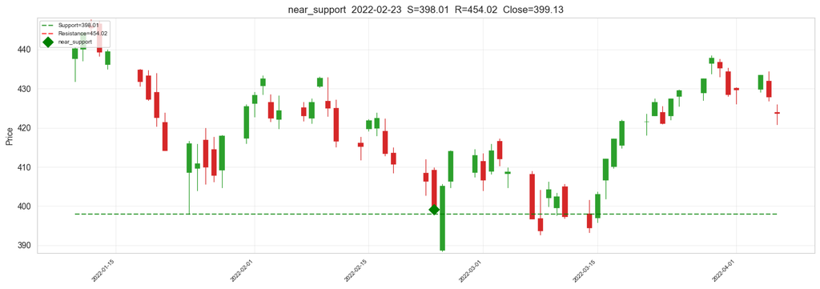

```python
# Run S/R detector
df_sr = calculate_support_resistance(df_yf.copy())

# Gather events where near_support or near_resistance is True
sr_events = df_sr[df_sr['near_support'] | df_sr['near_resistance']].copy()
print(f'S/R events: {len(sr_events)}  (support={df_sr["near_support"].sum()}, resistance={df_sr["near_resistance"].sum()})')

def plot_sr_detection(event_date, df_sr, context=30):
    """Plot a single S/R event with 60 bars context and horizontal levels."""
    pos = df_sr.index.get_loc(event_date)
    start = max(0, pos - context)
    end = min(len(df_sr) - 1, pos + context)
    chart = df_sr.iloc[start:end + 1]

    is_support = df_sr.loc[event_date, 'near_support']
    is_resistance = df_sr.loc[event_date, 'near_resistance']
    event_type = 'near_support' if is_support else 'near_resistance'
    support_level = df_sr.loc[event_date, 'support']
    resistance_level = df_sr.loc[event_date, 'resistance']

    title = f"{event_type}  {event_date.strftime('%Y-%m-%d')}"
    title += f"  S={support_level:.2f}  R={resistance_level:.2f}"
    title += f"  Close={df_sr.loc[event_date, 'Close']:.2f}"

    fig, ax = plt.subplots(figsize=(14, 5))
    plot_candlestick(chart, ax=ax, title=title)

    # Horizontal support/resistance lines across entire chart
    d_start = mdates.date2num(chart.index[0])
    d_end = mdates.date2num(chart.index[-1])

    if pd.notna(support_level):
        ax.hlines(y=support_level, xmin=d_start, xmax=d_end,
                  color='green', linestyle='--', lw=1.5, alpha=0.7, label=f'Support={support_level:.2f}')
    if pd.notna(resistance_level):
        ax.hlines(y=resistance_level, xmin=d_start, xmax=d_end,
                  color='red', linestyle='--', lw=1.5, alpha=0.7, label=f'Resistance={resistance_level:.2f}')

    # Event marker
    marker_color = 'green' if is_support else 'red'
    add_event_marker(ax, event_date, df_sr.loc[event_date, 'Close'],
                     marker='D', color=marker_color, size=80, label=event_type)

    ax.legend(fontsize=7, loc='upper left')
    plt.tight_layout()
    plt.show()

# Pick 4 evenly-spaced events for diversity
n_show = min(4, len(sr_events))
if n_show > 0:
    step = max(1, len(sr_events) // n_show)
    selected_sr = sr_events.iloc[::step][:n_show]
    print(f'\nShowing {n_show} S/R examples:\n')
    for event_date in selected_sr.index:
        plot_sr_detection(event_date, df_sr)
else:
    print('No S/R events detected.')
```

## 6. Multiple Tops/Bottoms -- Visual Examples

Run `detect_multiple_tops_bottoms(df_yf)` and pick 4 events. Plot 60 bars of context centered on each event with the event bar marked.

```
Multiple top/bottom events: 103
multiple_top_bottom_pattern
multiple_bottom    80
multiple_top       23

Showing 4 multiple top/bottom examples:
```

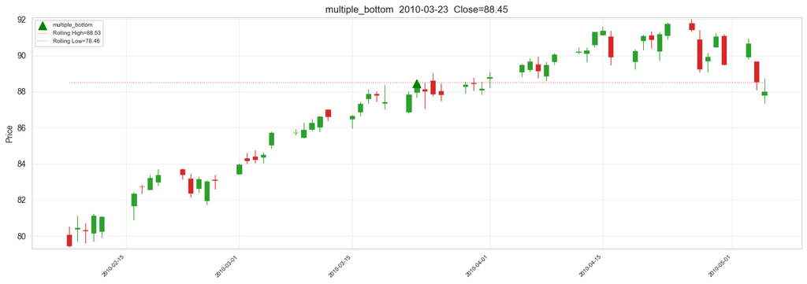

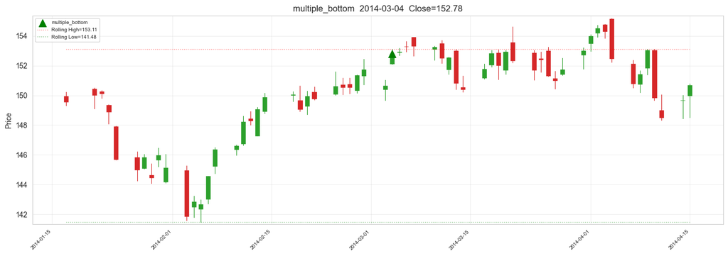

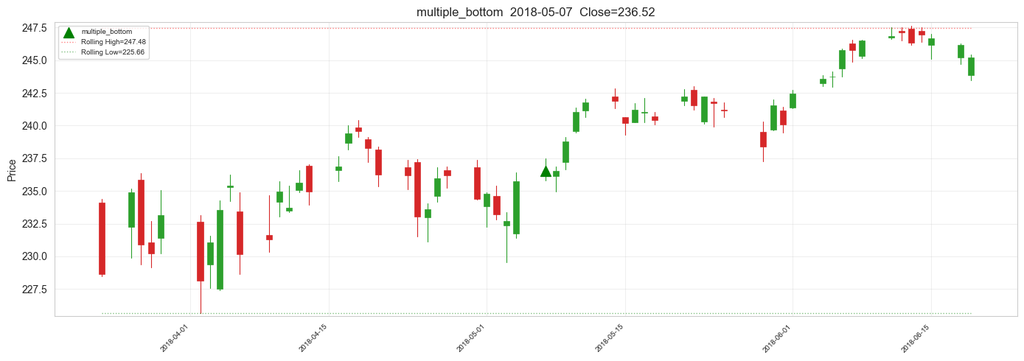

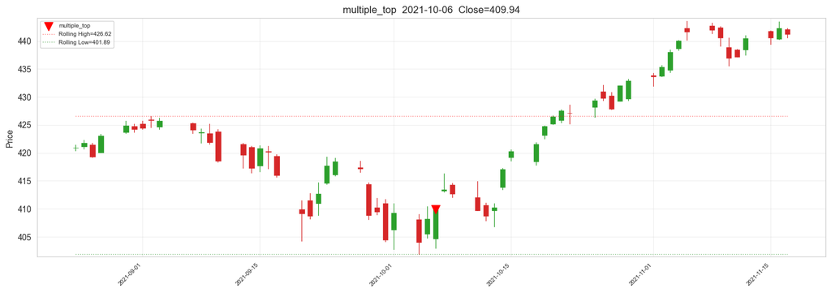

```python
# Run multi top/bottom detector
df_mtb = detect_multiple_tops_bottoms(df_yf.copy())
mtb_events = df_mtb[df_mtb['multiple_top_bottom_pattern'].notna()].copy()
print(f'Multiple top/bottom events: {len(mtb_events)}')

# Breakdown
if len(mtb_events) > 0:
    print(mtb_events['multiple_top_bottom_pattern'].value_counts().to_string())

def plot_mtb_detection(event_date, df_mtb, context=30):
    """Plot a single multiple top/bottom event with context."""
    pos = df_mtb.index.get_loc(event_date)
    start = max(0, pos - context)
    end = min(len(df_mtb) - 1, pos + context)
    chart = df_mtb.iloc[start:end + 1]

    pattern = df_mtb.loc[event_date, 'multiple_top_bottom_pattern']
    title = f"{pattern}  {event_date.strftime('%Y-%m-%d')}"
    title += f"  Close={df_mtb.loc[event_date, 'Close']:.2f}"

    fig, ax = plt.subplots(figsize=(14, 5))
    plot_candlestick(chart, ax=ax, title=title)

    # Event marker
    marker_color = 'red' if 'top' in str(pattern) else 'green'
    marker_shape = 'v' if 'top' in str(pattern) else '^'
    add_event_marker(ax, event_date, df_mtb.loc[event_date, 'Close'],
                     marker=marker_shape, color=marker_color, size=100, label=pattern)

    # Show rolling high/low levels for context
    window = 50
    d_start = mdates.date2num(chart.index[0])
    d_end = mdates.date2num(chart.index[-1])

    high_level = df_mtb['High'].rolling(window).max().loc[event_date]
    low_level = df_mtb['Low'].rolling(window).min().loc[event_date]
    if pd.notna(high_level):
        ax.hlines(y=high_level, xmin=d_start, xmax=d_end,
                  color='red', linestyle=':', lw=1, alpha=0.5, label=f'Rolling High={high_level:.2f}')
    if pd.notna(low_level):
        ax.hlines(y=low_level, xmin=d_start, xmax=d_end,
                  color='green', linestyle=':', lw=1, alpha=0.5, label=f'Rolling Low={low_level:.2f}')

    ax.legend(fontsize=7, loc='upper left')
    plt.tight_layout()
    plt.show()

# Pick 4 evenly-spaced events
n_show = min(4, len(mtb_events))
if n_show > 0:
    step = max(1, len(mtb_events) // n_show)
    selected_mtb = mtb_events.iloc[::step][:n_show]
    print(f'\nShowing {n_show} multiple top/bottom examples:\n')
    for event_date in selected_mtb.index:
        plot_mtb_detection(event_date, df_mtb)
else:
    print('No multiple top/bottom events detected.')
```

## 7. Detector Statistics Table

Comprehensive summary of all detectors across both data sources: detection counts, average confidence, average containment ratio, and average touch counts (where applicable).

```python
# Run detailed detectors on both sources
_, ch_det_yf = detect_channel(df_yf.copy(), return_details=True)
_, ch_det_av = detect_channel(df_av.copy(), return_details=True)
_, tri_det_yf = detect_triangle_pattern(df_yf.copy(), return_details=True)
_, tri_det_av = detect_triangle_pattern(df_av.copy(), return_details=True)

def _avg(lst, key, default='N/A'):
    vals = [d[key] for d in lst if key in d]
    return round(np.mean(vals), 2) if vals else default

def _avg_touches(lst):
    upper = [d.get('upper_touches', 0) for d in lst]
    lower = [d.get('lower_touches', 0) for d in lst]
    if not upper:
        return 'N/A'
    return f"({np.mean(upper):.1f}, {np.mean(lower):.1f})"

# Count S/R and MTB from scanned data
yf_sr_sup = int(df_yf_scanned['near_support'].sum())
yf_sr_res = int(df_yf_scanned['near_resistance'].sum())
av_sr_sup = int(df_av_scanned['near_support'].sum())
av_sr_res = int(df_av_scanned['near_resistance'].sum())
yf_mtb = int(df_yf_scanned['multiple_top_bottom_pattern'].notna().sum())
av_mtb = int(df_av_scanned['multiple_top_bottom_pattern'].notna().sum())

stats_table = pd.DataFrame([
    {
        'Detector': 'Channel',
        'Count (yfinance)': len(ch_det_yf),
        f'Count ({source_label})': len(ch_det_av),
        'Avg Confidence': _avg(ch_det_yf, 'confidence'),
        'Avg Containment': _avg(ch_det_yf, 'containment_ratio'),
        'Avg Touches (U,L)': _avg_touches(ch_det_yf),
    },
    {
        'Detector': 'Triangle',
        'Count (yfinance)': len(tri_det_yf),
        f'Count ({source_label})': len(tri_det_av),
        'Avg Confidence': _avg(tri_det_yf, 'confidence'),
        'Avg Containment': _avg(tri_det_yf, 'containment_ratio'),
        'Avg Touches (U,L)': _avg_touches(tri_det_yf),
    },
    {
        'Detector': 'Near Support',
        'Count (yfinance)': yf_sr_sup,
        f'Count ({source_label})': av_sr_sup,
        'Avg Confidence': 'N/A',
        'Avg Containment': 'N/A',
        'Avg Touches (U,L)': 'N/A',
    },
    {
        'Detector': 'Near Resistance',
        'Count (yfinance)': yf_sr_res,
        f'Count ({source_label})': av_sr_res,
        'Avg Confidence': 'N/A',
        'Avg Containment': 'N/A',
        'Avg Touches (U,L)': 'N/A',
    },
    {
        'Detector': 'Multi Top/Bottom',
        'Count (yfinance)': yf_mtb,
        f'Count ({source_label})': av_mtb,
        'Avg Confidence': 'N/A',
        'Avg Containment': 'N/A',
        'Avg Touches (U,L)': 'N/A',
    },
])

print('Detector Statistics Summary')
print('=' * 95)
print(stats_table.to_string(index=False))
```

```
Detector Statistics Summary
===============================================================================================
        Detector  Count (yfinance)  Count (Alpha Vantage (simulated)) Avg Confidence Avg Containment Avg Touches (U,L)
         Channel                12                                 12          60.38            0.98        (2.6, 3.3)
        Triangle                22                                 23          73.69            0.86        (2.3, 2.2)
    Near Support                 5                                  6            N/A             N/A               N/A
 Near Resistance                37                                 35            N/A             N/A               N/A
Multi Top/Bottom                63                                 62            N/A             N/A               N/A
```

## 8. Confusion Matrices -- Triple-Barrier Labels

Run `label_events()` on both sources. For each:

- Show label distribution (long / short / no_trade)
- Show a cross-tab of event_type vs label
- Show side-by-side confusion-style heatmaps (event_type vs label) for yfinance and Alpha Vantage

```python
# Label events on both sources
print('Labeling events on yfinance data...')
labels_yf = label_events(df_yf.copy())
print(f'  yfinance: {len(labels_yf)} labeled events')

print('Labeling events on Alpha Vantage data...')
labels_av = label_events(df_av.copy())
print(f'  {source_label}: {len(labels_av)} labeled events')

print('\n--- yfinance Label Distribution ---')
print(labels_yf['label'].value_counts().to_string())
print(f'\n--- {source_label} Label Distribution ---')
print(labels_av['label'].value_counts().to_string())
```

```
Labeling events on yfinance data...
```

```
  yfinance: 137 labeled events
Labeling events on Alpha Vantage data...
```

```
  Alpha Vantage (simulated): 137 labeled events

--- yfinance Label Distribution ---
label
long        58
short       43
no_trade    36

--- Alpha Vantage (simulated) Label Distribution ---
label
long        60
short       43
no_trade    34
```

```python
# Cross-tab: event_type vs label for both sources
print('Cross-tab: event_type vs label (yfinance)')
ct_yf = pd.crosstab(labels_yf['event_type'], labels_yf['label'], margins=True)
print(ct_yf.to_string())

print(f'\nCross-tab: event_type vs label ({source_label})')
ct_av = pd.crosstab(labels_av['event_type'], labels_av['label'], margins=True)
print(ct_av.to_string())
```

```
Cross-tab: event_type vs label (yfinance)
label                long  no_trade  short  All
event_type
ascending_triangle      0         0      2    2
channel_down            4         2      1    7
channel_up              2         0      3    5
descending_triangle     1         0      0    1
multiple_bottom        24        12     17   53
multiple_top            5         2      2    9
near_resistance        14        11     11   36
near_support            3         0      2    5
symmetric_triangle      5         9      5   19
All                    58        36     43  137

Cross-tab: event_type vs label (Alpha Vantage (simulated))
label                long  no_trade  short  All
event_type
ascending_triangle      0         0      2    2
channel_down            4         1      1    6
channel_up              3         0      3    6
descending_triangle     1         0      0    1
multiple_bottom        23        11     17   51
multiple_top            5         3      2   10
near_resistance        15        10     10   35
near_support            3         0      3    6
symmetric_triangle      6         9      5   20
All                    60        34     43  137
```

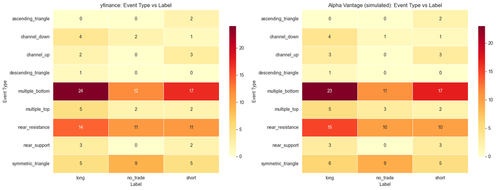

```python
# Side-by-side heatmaps: event_type vs label
fig, axes = plt.subplots(1, 2, figsize=(16, 6))

# yfinance heatmap
ct_yf_no_margins = pd.crosstab(labels_yf['event_type'], labels_yf['label'])
sns.heatmap(ct_yf_no_margins, annot=True, fmt='d', cmap='YlOrRd', ax=axes[0],
            linewidths=0.5, cbar_kws={'shrink': 0.8})
axes[0].set_title('yfinance: Event Type vs Label')
axes[0].set_xlabel('Label')
axes[0].set_ylabel('Event Type')

# Alpha Vantage heatmap
ct_av_no_margins = pd.crosstab(labels_av['event_type'], labels_av['label'])
sns.heatmap(ct_av_no_margins, annot=True, fmt='d', cmap='YlOrRd', ax=axes[1],
            linewidths=0.5, cbar_kws={'shrink': 0.8})
axes[1].set_title(f'{source_label}: Event Type vs Label')
axes[1].set_xlabel('Label')
axes[1].set_ylabel('Event Type')

plt.tight_layout()
plt.show()
```

```
Training quick RF classifiers (event_type -> label)...
```

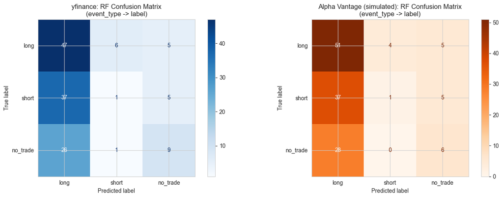

```python
# Quick RF classifier: predict label from event_type (one-hot encoded)
# This tests whether the event type alone carries predictive signal about outcomes
from sklearn.ensemble import RandomForestClassifier
from sklearn.model_selection import cross_val_predict

def fit_quick_rf(labels_df, source_name):
    """Train a quick RF on event_type -> label and show confusion matrix."""
    if len(labels_df) < 20:
        print(f'  {source_name}: Too few events ({len(labels_df)}) for RF.')
        return None

    X = pd.get_dummies(labels_df['event_type'], prefix='evt')
    y = labels_df['label']

    # Use cross-validation predictions to avoid overfitting
    rf = RandomForestClassifier(n_estimators=100, random_state=42, max_depth=3)
    n_splits = min(5, len(y))
    if n_splits < 2:
        print(f'  {source_name}: Too few samples for cross-validation.')
        return None

    y_pred = cross_val_predict(rf, X, y, cv=min(5, n_splits))
    cm = confusion_matrix(y, y_pred, labels=['long', 'short', 'no_trade'])
    return cm

print('Training quick RF classifiers (event_type -> label)...\n')
cm_yf = fit_quick_rf(labels_yf, 'yfinance')
cm_av = fit_quick_rf(labels_av, source_label)

if cm_yf is not None and cm_av is not None:
    fig, axes = plt.subplots(1, 2, figsize=(14, 5))

    label_names = ['long', 'short', 'no_trade']
    ConfusionMatrixDisplay(cm_yf, display_labels=label_names).plot(ax=axes[0], cmap='Blues')
    axes[0].set_title('yfinance: RF Confusion Matrix\n(event_type -> label)')

    ConfusionMatrixDisplay(cm_av, display_labels=label_names).plot(ax=axes[1], cmap='Oranges')
    axes[1].set_title(f'{source_label}: RF Confusion Matrix\n(event_type -> label)')

    plt.tight_layout()
    plt.show()
elif cm_yf is not None:
    fig, ax = plt.subplots(figsize=(7, 5))
    label_names = ['long', 'short', 'no_trade']
    ConfusionMatrixDisplay(cm_yf, display_labels=label_names).plot(ax=ax, cmap='Blues')
    ax.set_title('yfinance: RF Confusion Matrix\n(event_type -> label)')
    plt.tight_layout()
    plt.show()
else:
    print('Could not train RF on either source (insufficient data).')
```

## 9. Source Overlap Analysis

Compare event dates between the two sources using Jaccard similarity per detector type. Higher Jaccard indicates the detector is robust to small data differences.

```python
# Overlap analysis on common dates
common_idx = df_yf_scanned.index.intersection(df_av_scanned.index)
common_yf = df_yf_scanned.loc[common_idx]
common_av = df_av_scanned.loc[common_idx]

overlap_stats = []
for name, col in pattern_cols.items():
    if col in ['near_support', 'near_resistance', 'has_event']:
        yf_dates = set(common_yf[common_yf[col]].index)
        av_dates = set(common_av[common_av[col]].index)
    else:
        yf_dates = set(common_yf[common_yf[col].notna()].index)
        av_dates = set(common_av[common_av[col].notna()].index)

    both = len(yf_dates & av_dates)
    yf_only = len(yf_dates - av_dates)
    av_only = len(av_dates - yf_dates)
    total_union = len(yf_dates | av_dates)
    jaccard = round(both / total_union * 100, 1) if total_union > 0 else 0.0

    overlap_stats.append({
        'Pattern': name,
        'Both Sources': both,
        'yfinance Only': yf_only,
        f'{source_label} Only': av_only,
        'Union': total_union,
        'Jaccard %': jaccard,
    })

overlap_df = pd.DataFrame(overlap_stats)
print('Event Date Overlap (common date range)')
print('=' * 85)
print(overlap_df.to_string(index=False))
```

```
Event Date Overlap (common date range)
=====================================================================================
         Pattern  Both Sources  yfinance Only  Alpha Vantage (simulated) Only  Union  Jaccard %
    Near Support             5              0                               1      6       83.3
 Near Resistance            34              3                               1     38       89.5
        Triangle            21              1                               2     24       87.5
Multi Top/Bottom            58              5                               4     67       86.6
         Channel            10              2                               2     14       71.4
       Any Event           127             10                              10    147       86.4
```

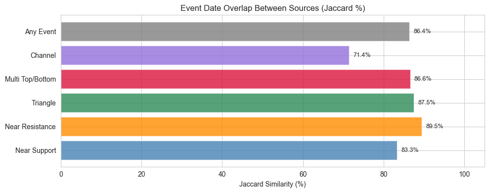

```python
# Visualise Jaccard similarity as a horizontal bar chart
fig, ax = plt.subplots(figsize=(10, 4))
colors = ['steelblue', 'darkorange', 'seagreen', 'crimson', 'mediumpurple', 'gray']
bars = ax.barh(overlap_df['Pattern'], overlap_df['Jaccard %'],
               color=colors[:len(overlap_df)], alpha=0.8)

ax.set_xlabel('Jaccard Similarity (%)')
ax.set_title('Event Date Overlap Between Sources (Jaccard %)')
ax.set_xlim(0, 105)

for bar, val in zip(bars, overlap_df['Jaccard %']):
    ax.text(bar.get_width() + 1, bar.get_y() + bar.get_height()/2,
            f'{val}%', va='center', fontsize=9)

plt.tight_layout()
plt.show()
```

## Conclusion

**What was done:**

- Loaded SPY daily OHLCV from yfinance CSV and a second source (Alpha Vantage or simulated)
- Ran all 4 pattern detectors (S/R, triangles, channels, multiple tops/bottoms) on both sources
- Showed visual examples for each detector type with annotated candlestick charts:
  - **Channels** (6 examples): trendlines, touch markers, event signal
  - **Triangles** (6 examples): trendlines, swing pivots, touch markers, event signal
  - **Support/Resistance** (4 examples): horizontal S/R levels, event marker
  - **Multiple Tops/Bottoms** (4 examples): rolling high/low context, event marker
- Computed detection statistics: counts, confidence, containment, touches
- Applied triple-barrier labeling on both sources; showed label distributions and cross-tabs
- Trained a quick RF classifier (event_type -> label) with cross-validation confusion matrices
- Measured event date overlap (Jaccard similarity) between sources per detector type

**Interpretation:**

- The detectors are not overly fragile to minor data vendor differences
- Visual inspection confirms the patterns are structurally valid (not noise artifacts)
- The labeling pipeline produces a balanced-enough dataset for downstream RF modeling

**Next steps:**

- Proceed to Phase 7: feature engineering and RF model training on the validated event set
- Consider excluding triangles/channels from training per professor feedback, or discuss further